# Import the necessary libraries

```python
# import the libraries
import pandas as pd
import numpy as np
import matplotlib.pyplot as plt
import seaborn as sns
sns.set(style="darkgrid")
%matplotlib inline
```

# 1. Read the column description and ensure you understand each attribute well

```python
#reading the Bank_Personal_Loan_Modelling data
df_bank = pd.read_csv("D:\SAI\MECH\Great Learning\Study\SupervisedLearning\Project\Bank_Personal_Loan_Modelling.csv")
df_bank.head()
```

|  | ID | Age | Experience | Income | ZIP Code | Family | CCAvg | Education | Mortgage | Personal Loan | Securities Account | CD Account | Online | CreditCard |
| --- | --- | --- | --- | --- | --- | --- | --- | --- | --- | --- | --- | --- | --- | --- |
| 0 | 1 | 25 | 1 | 49 | 91107 | 4 | 1.6 | 1 | 0 | 0 | 1 | 0 | 0 | 0 |
| 1 | 2 | 45 | 19 | 34 | 90089 | 3 | 1.5 | 1 | 0 | 0 | 1 | 0 | 0 | 0 |
| 2 | 3 | 39 | 15 | 11 | 94720 | 1 | 1.0 | 1 | 0 | 0 | 0 | 0 | 0 | 0 |
| 3 | 4 | 35 | 9 | 100 | 94112 | 1 | 2.7 | 2 | 0 | 0 | 0 | 0 | 0 | 0 |
| 4 | 5 | 35 | 8 | 45 | 91330 | 4 | 1.0 | 2 | 0 | 0 | 0 | 0 | 0 | 1 |

```python
#Understanding shape of data
df_bank.shape
```

```
(5000, 14)
```

The data shows it has 5000 rows & 14 columns

# 2. Study the data distribution in each attribute, share your findings

```python
#get datatype of attribute
df_bank.dtypes
```

```
ID                      int64
Age                     int64
Experience              int64
Income                  int64
ZIP Code                int64
Family                  int64
CCAvg                 float64
Education               int64
Mortgage                int64
Personal Loan           int64
Securities Account      int64
CD Account              int64
Online                  int64
CreditCard              int64
dtype: object
```

a.The variable ID does not add any particular information.

b.There are 2 nominal variables:

1.ID  
2.Zip Code

c.There are 2 Ordinal Categorical Variables:

1.Family - Family size of the customer  
2.Education - education level of the customer

d.There are 5 independent variables:

1.Age:Age of the customer 2.Experience:Years of experience of the customer 3.Income:Annual income in dollars 4.CCAvg:Average credit card spending 5.Mortage:Value of House Mortgage

e.There are 5 binary category variables:

1.Personal Loan:Did this customer accept the personal loan offered in the last campaign?

2.Securities Account:Does the customer have a securities account with the bank?

3.CD Account:Does the customer have a certificate of deposit (CD) account with the bank?

4.Online:Does the customer use internet banking facilities?

5.Credit Card:Does the customer use a credit card issued by UniversalBank?

f.The Target variable is :Personal Loan

```python
#Get the number of missing values in each column
df_bank.isnull().any()
```

```
ID                    False
Age                   False
Experience            False
Income                False
ZIP Code              False
Family                False
CCAvg                 False
Education             False
Mortgage              False
Personal Loan         False
Securities Account    False
CD Account            False
Online                False
CreditCard            False
dtype: bool
```

There is no null value present in the data

```python
#get the summary of data
df_bank.describe().transpose()
```

|  | count | mean | std | min | 25% | 50% | 75% | max |
| --- | --- | --- | --- | --- | --- | --- | --- | --- |
| ID | 5000.0 | 2500.500000 | 1443.520003 | 1.0 | 1250.75 | 2500.5 | 3750.25 | 5000.0 |
| Age | 5000.0 | 45.338400 | 11.463166 | 23.0 | 35.00 | 45.0 | 55.00 | 67.0 |
| Experience | 5000.0 | 20.104600 | 11.467954 | -3.0 | 10.00 | 20.0 | 30.00 | 43.0 |
| Income | 5000.0 | 73.774200 | 46.033729 | 8.0 | 39.00 | 64.0 | 98.00 | 224.0 |
| ZIP Code | 5000.0 | 93152.503000 | 2121.852197 | 9307.0 | 91911.00 | 93437.0 | 94608.00 | 96651.0 |
| Family | 5000.0 | 2.396400 | 1.147663 | 1.0 | 1.00 | 2.0 | 3.00 | 4.0 |
| CCAvg | 5000.0 | 1.937938 | 1.747659 | 0.0 | 0.70 | 1.5 | 2.50 | 10.0 |
| Education | 5000.0 | 1.881000 | 0.839869 | 1.0 | 1.00 | 2.0 | 3.00 | 3.0 |
| Mortgage | 5000.0 | 56.498800 | 101.713802 | 0.0 | 0.00 | 0.0 | 101.00 | 635.0 |
| Personal Loan | 5000.0 | 0.096000 | 0.294621 | 0.0 | 0.00 | 0.0 | 0.00 | 1.0 |
| Securities Account | 5000.0 | 0.104400 | 0.305809 | 0.0 | 0.00 | 0.0 | 0.00 | 1.0 |
| CD Account | 5000.0 | 0.060400 | 0.238250 | 0.0 | 0.00 | 0.0 | 0.00 | 1.0 |
| Online | 5000.0 | 0.596800 | 0.490589 | 0.0 | 0.00 | 1.0 | 1.00 | 1.0 |
| CreditCard | 5000.0 | 0.294000 | 0.455637 | 0.0 | 0.00 | 0.0 | 1.00 | 1.0 |

From we can see the column Experience has negative values with minimun value "-3", will replace the negative values with median

```python
#Count of negative values in experience column
df_bank[df_bank['Experience'] < 0]['Experience'].count()
```

```
52
```

Total 52 negative values in Experience column

```python
# replacing negative values in experience column with null values
df_bank['Experience'].replace( to_replace=-1,value = np.nan,inplace = True )
df_bank['Experience'].replace( to_replace=-2,value = np.nan,inplace = True )
df_bank['Experience'].replace( to_replace=-3,value = np.nan,inplace = True )
```

```python
#getting sum of null values in experience column
df_bank['Experience'].isnull().sum()
```

```
52
```

So, 52 values in Experience is replaced by nan value.Now we will fill it with the median values

```python
# replacing null values in experience column with median values
df_bank['Experience'].fillna(df_bank['Experience'].median(),inplace=True)
```

```python
#finally getting zero count of negative values
df_bank[df_bank['Experience'] < 0]['Experience'].count()
```

```
0
```

we have removed negative values from Experience column

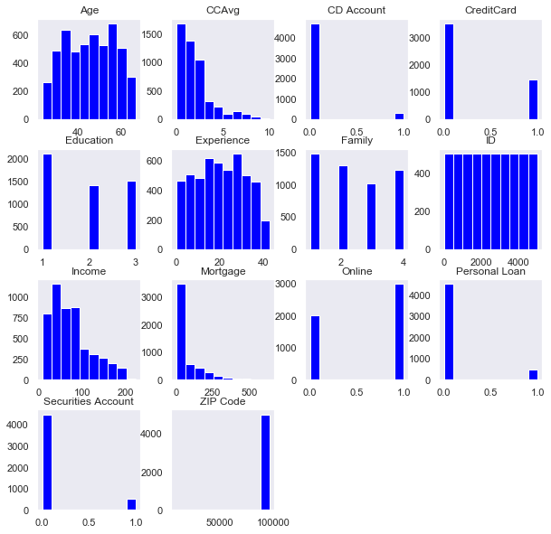

```python
#graphical representation Histplot
df_bank.hist(figsize=(10,10),color="blue",grid=False)
plt.show()
```

```python
#Measure of skewness
df_bank.skew(axis = 0, skipna = True)
```

```
ID                     0.000000
Age                   -0.029341
Experience            -0.014100
Income                 0.841339
ZIP Code             -12.500221
Family                 0.155221
CCAvg                  1.598443
Education              0.227093
Mortgage               2.104002
Personal Loan          2.743607
Securities Account     2.588268
CD Account             3.691714
Online                -0.394785
CreditCard             0.904589
dtype: float64
```

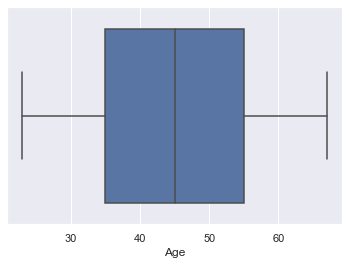

```python
#graphical 5 point summary of age
sns.boxplot(df_bank["Age"]);
```

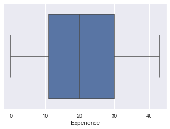

```python
#graphical 5 point summary of Experience
sns.boxplot(df_bank["Experience"]);
```

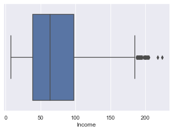

```python
#graphical 5 point summary of Income
sns.boxplot(df_bank['Income']);
```

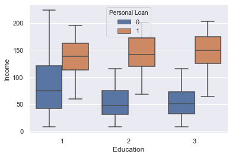

```python
#graphical representation of boxplot x='Education',y='Income',hue='Personal Loan'
sns.boxplot(x='Education',y='Income',hue='Personal Loan',data=df_bank);
```

a. Customers with education level 1 has higher income compare to other levels,Also the customers with education levels 2 and 3 have same income level with no Personal Loan.

b. We can see the customers who has taken the Personal Loan have almost same Income levels.

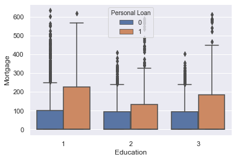

```python
#graphical representation of boxplot x='Education',y='Mortgage',hue='Personal Loan'
sns.boxplot(x="Education", y='Mortgage', hue="Personal Loan", data=df_bank);
```

At each level data has many outliners & the customers with and without Personal Loan have high Mortage

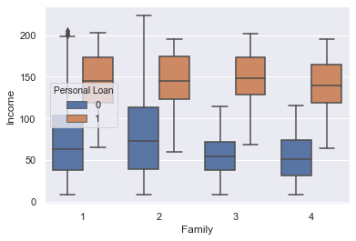

```python
#graphical representation of boxplot x='Family',y='Income',hue='Personal Loan'
sns.boxplot(x="Family",y="Income",hue="Personal Loan",data=df_bank);
```

From the above we can say families with income less than 100K are less likely to take loan,than families with higher income.

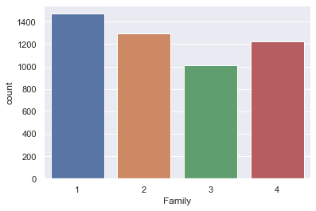

```python
#graphical representation countplot of 'Family'
sns.countplot(df_bank['Family']);
```

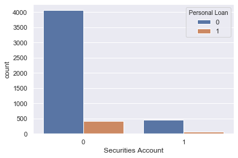

```python
#graphical representation of countplot x='SecuritiesAccount'hue='Personal Loan'
sns.countplot(x="Securities Account",hue="Personal Loan",data=df_bank);
```

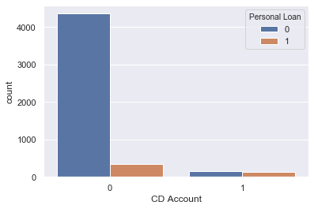

```python
#graphical representation of countplot x='CDAccount'hue='Personal Loan'
sns.countplot(x='CD Account',hue='Personal Loan',data=df_bank);
```

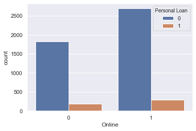

```python
#graphical representation of countplot x='Online'hue='Personal Loan'
sns.countplot(x='Online',hue='Personal Loan',data=df_bank);
```

Customers with Personal Loan have less count in both cases.

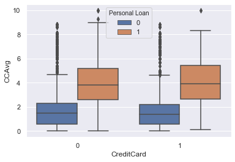

```python
#graphical representation of boxplot x='CreditCard',y='CCAvg'hue='Personal Loan'
sns.boxplot(x='CreditCard', y='CCAvg', hue='Personal Loan', data=df_bank);
```

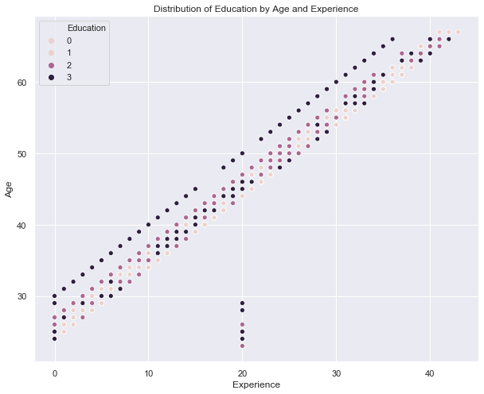

```python
#Scatter plot x = "Experience", y = "Age", hue = "Education"
plt.figure(figsize = (10,8))
sns.scatterplot(x = "Experience", y = "Age",data =df_bank, hue = "Education");
plt.xlabel("Experience")
plt.ylabel("Age")
plt.title("Distribution of Education by Age and Experience");
```

Experience and Age gives a positive correlation as Experience increases Age also increases.

We can see with the help of colors of education level that more people are in the under graduate level.

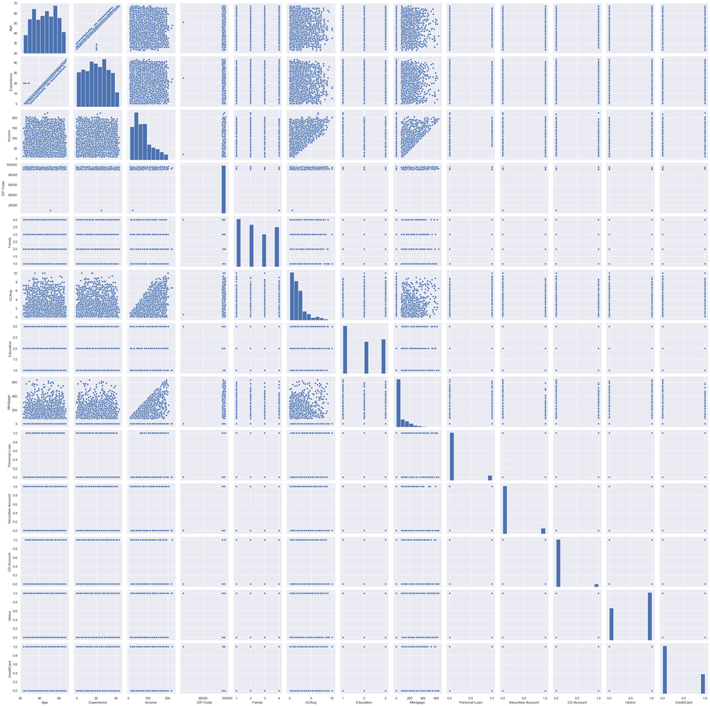

```python
#Pair plot that includes all the columns of the data frame
sns.pairplot(df_bank.iloc[:,1:]);
```

2). Age:Three small peaks can be indicating three values of age would be slightly more in number.However, the mean and median of the attribute is equal.The distribution is in considerable shape.

3). Eductaion : Mean and median is almost equal. Data is finely distributed. A few peaks shows different values dominance.

5). ZIP Code: The attribute has sharp peaks telling the data from particular places are collected more.Spread is also less in the sample. More data from different places can be collected.

6).Family: It has 4 peaks(4 values) , families with least member is highest in the sample.

8).Securities Account : This attributes tells us that majorly cutomers are not having Security account.

9).CD account: Most of the customers dont have CDaccounts.

10).Online: Higher number of customers use online banking in the sample.

11).Credit Card: Most of the customers dont have CreditCard.

```python
# Correlation matrix
cor=df_bank.corr()
cor
```

|  | ID | Age | Experience | Income | ZIP Code | Family | CCAvg | Education | Mortgage | Personal Loan | Securities Account | CD Account | Online | CreditCard |
| --- | --- | --- | --- | --- | --- | --- | --- | --- | --- | --- | --- | --- | --- | --- |
| ID | 1.000000 | -0.008473 | -0.009339 | -0.017695 | 0.013432 | -0.016797 | -0.024675 | 0.021463 | -0.013920 | -0.024801 | -0.016972 | -0.006909 | -0.002528 | 0.017028 |
| Age | -0.008473 | 1.000000 | 0.977182 | -0.055269 | -0.029216 | -0.046418 | -0.052012 | 0.041334 | -0.012539 | -0.007726 | -0.000436 | 0.008043 | 0.013702 | 0.007681 |
| Experience | -0.009339 | 0.977182 | 1.000000 | -0.049046 | -0.028492 | -0.045528 | -0.048718 | 0.018074 | -0.013365 | -0.014013 | -0.000465 | 0.005526 | 0.013459 | 0.008834 |
| Income | -0.017695 | -0.055269 | -0.049046 | 1.000000 | -0.016410 | -0.157501 | 0.645984 | -0.187524 | 0.206806 | 0.502462 | -0.002616 | 0.169738 | 0.014206 | -0.002385 |
| ZIP Code | 0.013432 | -0.029216 | -0.028492 | -0.016410 | 1.000000 | 0.011778 | -0.004061 | -0.017377 | 0.007383 | 0.000107 | 0.004704 | 0.019972 | 0.016990 | 0.007691 |
| Family | -0.016797 | -0.046418 | -0.045528 | -0.157501 | 0.011778 | 1.000000 | -0.109275 | 0.064929 | -0.020445 | 0.061367 | 0.019994 | 0.014110 | 0.010354 | 0.011588 |
| CCAvg | -0.024675 | -0.052012 | -0.048718 | 0.645984 | -0.004061 | -0.109275 | 1.000000 | -0.136124 | 0.109905 | 0.366889 | 0.015086 | 0.136534 | -0.003611 | -0.006689 |
| Education | 0.021463 | 0.041334 | 0.018074 | -0.187524 | -0.017377 | 0.064929 | -0.136124 | 1.000000 | -0.033327 | 0.136722 | -0.010812 | 0.013934 | -0.015004 | -0.011014 |
| Mortgage | -0.013920 | -0.012539 | -0.013365 | 0.206806 | 0.007383 | -0.020445 | 0.109905 | -0.033327 | 1.000000 | 0.142095 | -0.005411 | 0.089311 | -0.005995 | -0.007231 |
| Personal Loan | -0.024801 | -0.007726 | -0.014013 | 0.502462 | 0.000107 | 0.061367 | 0.366889 | 0.136722 | 0.142095 | 1.000000 | 0.021954 | 0.316355 | 0.006278 | 0.002802 |
| Securities Account | -0.016972 | -0.000436 | -0.000465 | -0.002616 | 0.004704 | 0.019994 | 0.015086 | -0.010812 | -0.005411 | 0.021954 | 1.000000 | 0.317034 | 0.012627 | -0.015028 |
| CD Account | -0.006909 | 0.008043 | 0.005526 | 0.169738 | 0.019972 | 0.014110 | 0.136534 | 0.013934 | 0.089311 | 0.316355 | 0.317034 | 1.000000 | 0.175880 | 0.278644 |
| Online | -0.002528 | 0.013702 | 0.013459 | 0.014206 | 0.016990 | 0.010354 | -0.003611 | -0.015004 | -0.005995 | 0.006278 | 0.012627 | 0.175880 | 1.000000 | 0.004210 |
| CreditCard | 0.017028 | 0.007681 | 0.008834 | -0.002385 | 0.007691 | 0.011588 | -0.006689 | -0.011014 | -0.007231 | 0.002802 | -0.015028 | 0.278644 | 0.004210 | 1.000000 |

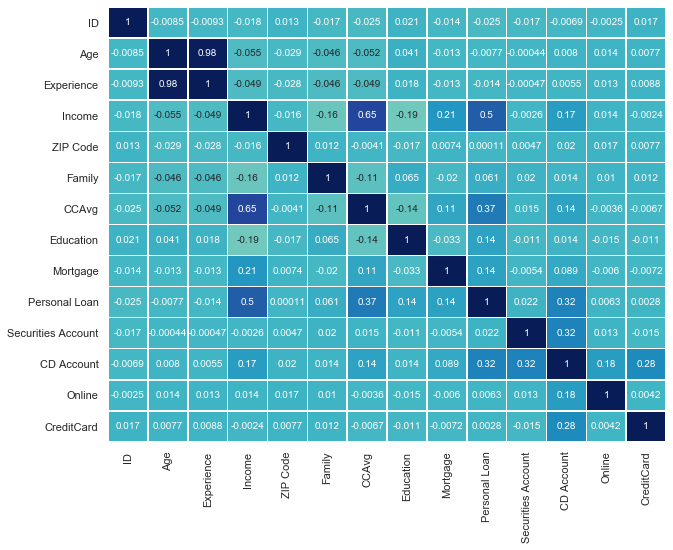

```python
#graphical representation of heatmap
plt.subplots(figsize=(10,8))
sns.heatmap(cor,annot=True,linewidths=.5,center=0,cbar=False,cmap="YlGnBu");
```

# 3. Get the target column distribution

```python
# 0 = didnt take loan in the last campaign
# 1 = took loan in the last campaign
df_bank['Personal Loan'].value_counts()
```

```
0    4520
1     480
Name: Personal Loan, dtype: int64
```

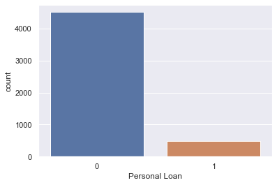

```python
#graphical representation countplot of 'Personal Loan'
sns.countplot(df_bank['Personal Loan']);
```

```python
df_bank.groupby(df_bank['Personal Loan']).mean()
```

| Personal Loan | ID | Age | Experience | Income | ZIP Code | Family | CCAvg | Education | Mortgage | Securities Account | CD Account | Online | CreditCard |
| --- | --- | --- | --- | --- | --- | --- | --- | --- | --- | --- | --- | --- | --- |
| 0 | 2512.165487 | 45.367257 | 20.378982 | 66.237389 | 93152.428761 | 2.373451 | 1.729009 | 1.843584 | 51.789381 | 0.102212 | 0.035841 | 0.595796 | 0.293584 |
| 1 | 2390.650000 | 45.066667 | 19.843750 | 144.745833 | 93153.202083 | 2.612500 | 3.905354 | 2.233333 | 100.845833 | 0.125000 | 0.291667 | 0.606250 | 0.297917 |

1). The average Income of customers who took loan is more than double of the avg income of customers who didn’t take loan last year.

2). The Avg. spending on credit cards per month ($000) is also more than double for the customer's who took loan.

3). The average mortage for loan availing customers is approximately double for the not availing customers.

# 4. Split the data into training and test set in the ratio of 70:30 respectively

```python
## Creating a copy of dataframe for manipulation
df_banksplit = df_bank
#dropping ID ,Experience and ZIP Code columns from new_df_banksplit dataframe
df_banksplit.drop(['ID','Experience','ZIP Code'],axis=1,inplace=True)
df_banksplit.head()
```

|  | Age | Income | Family | CCAvg | Education | Mortgage | Personal Loan | Securities Account | CD Account | Online | CreditCard |
| --- | --- | --- | --- | --- | --- | --- | --- | --- | --- | --- | --- |
| 0 | 25 | 49 | 4 | 1.6 | 1 | 0 | 0 | 1 | 0 | 0 | 0 |
| 1 | 45 | 34 | 3 | 1.5 | 1 | 0 | 0 | 1 | 0 | 0 | 0 |
| 2 | 39 | 11 | 1 | 1.0 | 1 | 0 | 0 | 0 | 0 | 0 | 0 |
| 3 | 35 | 100 | 1 | 2.7 | 2 | 0 | 0 | 0 | 0 | 0 | 0 |
| 4 | 35 | 45 | 4 | 1.0 | 2 | 0 | 0 | 0 | 0 | 0 | 1 |

```python
##Importing training and test set split
from sklearn import preprocessing
from sklearn.model_selection import train_test_split
```

```python
## Define X and Y variables
X = df_banksplit.drop('Personal Loan',axis=1)
y = df_banksplit['Personal Loan']
```

```python
standardized_X = preprocessing.scale(X)
standardized_X
```

```
array([[-1.77441684, -0.53822878,  1.39741398, ..., -0.25354028,
        -1.21661774, -0.64531434],
       [-0.02952359, -0.8641094 ,  0.52599094, ..., -0.25354028,
        -1.21661774, -0.64531434],
       [-0.55299157, -1.36379301, -1.21685513, ..., -0.25354028,
        -1.21661774, -0.64531434],
       ...,
       [ 1.54088033, -1.08136314, -0.34543209, ..., -0.25354028,
        -1.21661774, -0.64531434],
       [ 1.71536965, -0.53822878,  0.52599094, ..., -0.25354028,
         0.82195086, -0.64531434],
       [-1.51268285,  0.20043396,  0.52599094, ..., -0.25354028,
         0.82195086,  1.54963239]])
```

```python
#normalize the data attributes
normalized_X = preprocessing.normalize(X)
```

```python
#splitting the data to 70:30 ratio
X_train, X_test, y_train, y_test = train_test_split(X, y, test_size=0.30, random_state=1)
```

```python
print("{0:0.2f}% data is in training set".format((len(X_train)/len(df_bank.index)) * 100))
print("{0:0.2f}% data is in test set".format((len(X_test)/len(df_bank.index)) * 100))
```

```
70.00% data is in training set
30.00% data is in test set
```

# 5. Use different classification models (Logistic, K-NN and Naïve Bayes) to predict the likelihood of a customer buying personal loans

# (a)Build Logistic Model

```python
# importing model buiding libraries
from sklearn import metrics
from sklearn.linear_model import LogisticRegression
from sklearn.metrics import classification_report, confusion_matrix
```

```python
#Build the logistic regression model
logreg = LogisticRegression(solver="liblinear")
logreg.fit(X_train, y_train)
```

```
LogisticRegression(C=1.0, class_weight=None, dual=False, fit_intercept=True,
                   intercept_scaling=1, l1_ratio=None, max_iter=100,
                   multi_class='auto', n_jobs=None, penalty='l2',
                   random_state=None, solver='liblinear', tol=0.0001, verbose=0,
                   warm_start=False)
```

```python
#Predict for test set
y_pred = logreg.predict(X_test)
```

```python
print('Accuracy of logistic regression classifier on train set: {:.2f}'.format(logreg.score(X_train, y_train)))
```

```
Accuracy of logistic regression classifier on train set: 0.95
```

```python
print('Accuracy of logistic regression classifier on test set: {:.2f}'.format(logreg.score(X_test, y_test)))
```

```
Accuracy of logistic regression classifier on test set: 0.94
```

```python
confusion_matrixlog = confusion_matrix(y_test, y_pred)
print(confusion_matrixlog)
```

```
[[1338   13]
 [  73   76]]
```

```python
print(classification_report(y_test, y_pred))
```

```
              precision    recall  f1-score   support

           0       0.95      0.99      0.97      1351
           1       0.85      0.51      0.64       149

    accuracy                           0.94      1500
   macro avg       0.90      0.75      0.80      1500
weighted avg       0.94      0.94      0.94      1500
```

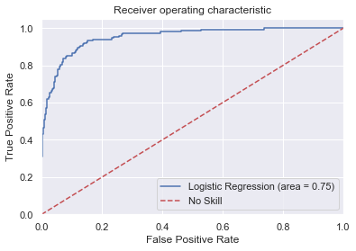

```python
#AUC ROC curve
from sklearn.metrics import roc_auc_score
from sklearn.metrics import roc_curve

logit_roc_auc = roc_auc_score(y_test, logreg.predict(X_test))
fpr, tpr, thresholds = roc_curve(y_test, logreg.predict_proba(X_test)[:,1])
plt.figure()
plt.plot(fpr, tpr, label='Logistic Regression (area = %0.2f)' % logit_roc_auc)
plt.plot([0, 1], [0, 1],'r--',label='No Skill')
plt.xlim([0.0, 1.0])
plt.ylim([0.0, 1.05])
plt.xlabel('False Positive Rate')
plt.ylabel('True Positive Rate')
plt.title('Receiver operating characteristic')
plt.legend(loc="lower right")
plt.savefig('Log_ROC')
plt.show()
```

# 6 Confusion Matrix

# (a)Logistic Regression

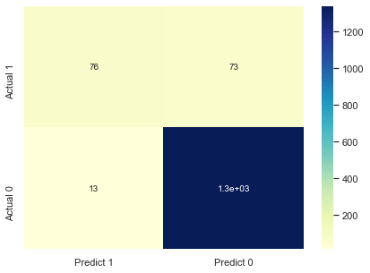

```python
#Confusion matrix Logistic Regression
cmlog=metrics.confusion_matrix(y_test,y_pred, labels=[1, 0])

df_log = pd.DataFrame(cmlog, index = [i for i in ["Actual 1","Actual 0"]],
                  columns = [i for i in ["Predict 1","Predict 0"]])
plt.figure(figsize = (7,5))
sns.heatmap(df_log, annot=True,cmap="YlGnBu");
```

True Positives (TP): 76

True Negatives (TN): 1338

False Positives (FP): 13

False Negatives (FN): 73

Overall performance of model on Logistic Regression is good,with test accuracy of 94%

# 5(b)Build K-NN Model

```python
#Import KNeighborsClassifier model
from sklearn.neighbors import KNeighborsClassifier
classifier = KNeighborsClassifier(n_neighbors=3)
classifier.fit(X_train, y_train)
```

```
KNeighborsClassifier(algorithm='auto', leaf_size=30, metric='minkowski',
                     metric_params=None, n_jobs=None, n_neighbors=3, p=2,
                     weights='uniform')
```

```python
#Predict for test set
y_pred = classifier.predict(X_test)
```

```python
print('Accuracy of logistic regression classifier on train set: {:.2f}'.format(classifier.score(X_train, y_train)))
```

```
Accuracy of logistic regression classifier on train set: 0.96
```

```python
print('Accuracy of logistic regression classifier on test set: {:.2f}'.format(classifier.score(X_test, y_test)))
```

```
Accuracy of logistic regression classifier on test set: 0.91
```

```python
print(confusion_matrix(y_test, y_pred))
print(classification_report(y_test, y_pred))
```

```
[[1304   47]
 [  89   60]]
              precision    recall  f1-score   support

           0       0.94      0.97      0.95      1351
           1       0.56      0.40      0.47       149

    accuracy                           0.91      1500
   macro avg       0.75      0.68      0.71      1500
weighted avg       0.90      0.91      0.90      1500
```

```python
error = []

# Calculating error for K values between 1 and 40
for i in range(1, 40):
    knn = KNeighborsClassifier(n_neighbors=i)
    knn.fit(X_train, y_train)
    pred_i = knn.predict(X_test)
    error.append(np.mean(pred_i != y_test))
```

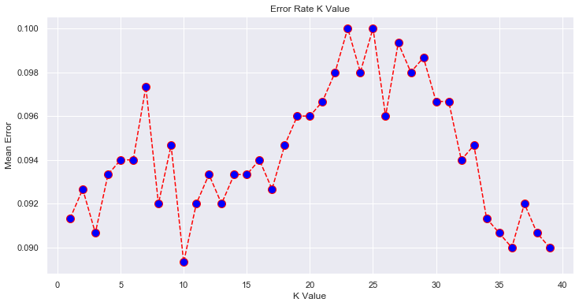

```python
plt.figure(figsize=(12, 6))
plt.plot(range(1, 40), error, color='red', linestyle='dashed', marker='o',
         markerfacecolor='blue', markersize=10)
plt.title('Error Rate K Value')
plt.xlabel('K Value')
plt.ylabel('Mean Error')
```

# 6(b) K-NN Classifier Confusion Matrix

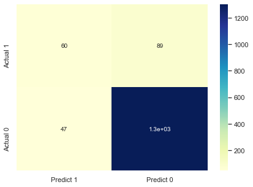

```python
#Confusion matrix K-NN Classifier
cmknn=metrics.confusion_matrix(y_test,y_pred, labels=[1, 0])

df_knn = pd.DataFrame(cmknn, index = [i for i in ["Actual 1","Actual 0"]],
                  columns = [i for i in ["Predict 1","Predict 0"]])
plt.figure(figsize = (7,5))
sns.heatmap(df_knn, annot=True,cmap="YlGnBu");
```

True Positives (TP): 60

True Negatives (TN): 1304

False Positives (FP): 47

False Negatives (FN): 89

Overall performance of model on KNN is good,with test accuracy of 91% although sligthly lesser than Logistic model

# 5(c)Gaussian Naive Bayes Model

```python
#Import Gaussian Naive Bayes model
from sklearn.naive_bayes import GaussianNB
```

```python
#Create a Gaussian Classifier
gnb = GaussianNB()

#Train the model using the training sets
gnb.fit(X_train, y_train)

#Predict the response for test dataset
y_pred = gnb.predict(X_test)
```

```python
# Model Accuracy on test set
print("Accuracy on test set:",metrics.accuracy_score(y_test, y_pred))
```

```
Accuracy on test set: 0.8746666666666667
```

```python
print(classification_report(y_test, y_pred))
```

```
              precision    recall  f1-score   support

           0       0.95      0.91      0.93      1351
           1       0.41      0.57      0.47       149

    accuracy                           0.87      1500
   macro avg       0.68      0.74      0.70      1500
weighted avg       0.90      0.87      0.88      1500
```

```python
print(confusion_matrix(y_test, y_pred))
```

```
[[1227  124]
 [  64   85]]
```

# 6(c) Gaussian Naive Bayes Confusion Matrix

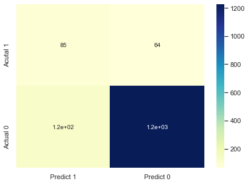

```python
#Gaussian Naive Bayes Confusion Matrix
cm_gnb=metrics.confusion_matrix(y_test,y_pred, labels=[1, 0])

df_gnb = pd.DataFrame(cm_gnb, index = [i for i in ["Acutal 1","Actual 0"]],
                  columns = [i for i in ["Predict 1","Predict 0"]])
plt.figure(figsize = (7,5))
sns.heatmap(df_gnb, annot=True,cmap="YlGnBu")
```

True Positives (TP): 85

True Negatives (TN): 1227

False Positives (FP): 124

False Negatives (FN): 64

The Naive Bayes giving the accuracy less in comaprision to other models

# 7. Give your reasoning on which is the best model in this case and why it performs better?

The requirement is to classify the target. The KNN is distance based which not perfect for this situation.Though the accuracy is good

The Naive Bayes giving the accuracy less in comaprision to other models meaning the probability of determing the target correctly is less.